# Strouse_Logan

##### (5) (6 points) The Cauchy distribution is an example of a “heavy-tailed” distribution in that it will have (more) outliers in both tails. This problem involves comparing it with a normal distribution which typically has very few outliers.

5(a) Use *set.seed(124)* and *rcauchy()* with n = 100, location = 0 and scale = 0.1 to generate a random sample designated as y. Generate a second random sample designated as x with *set.seed(127)* and *rnorm()* using n = 100, mean = 0 and sd = 0.15.

For information about rcauchy(), use help in R (?rcauchy). **Do not print x and y.**

```r
set.seed(124)
y=rcauchy(100,0,.1)
set.seed(127)
x=rnorm(100,0,.15)
object=cbind(x,y)
IQR=apply(object,2,median)
round(IQR,digits = 4)
```

```
##      x      y
## 0.0004 0.0536
```

(5)(b) This item will illustrate the difference between a heavy-tailed distribution and one which does not have heavy tails. Use *par(mfrow = c(2, 2))* to generate a display with four diagrams. On the first row, For the Normal results present a histogram and a horizontal boxplot for x in color. For the Cauchy results, present a histogram and a horizontal boxplot for y in color.

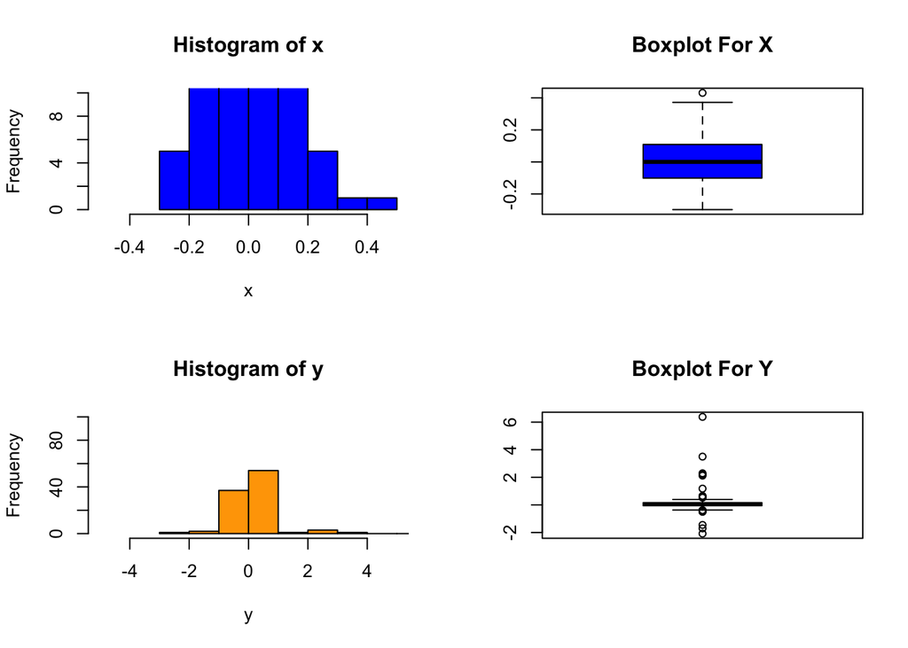

```r
#this entire problem I used a lot of adjustments to try and fit the data on the graph in a feasible manner through manipulating the xlim
par(mfrow = c(2, 2))
hist(x,xlim = c(-.5,.5),ylim =(c(0,10)),col="blue")
boxplot(x,col = "blue")
title("Boxplot For X")
hist(y,xlim=c(-5,5),ylim=c(0,100),col="orange")
boxplot(y,col = "orange")
title("Boxplot For Y")
```

(5)(c) QQ plots are useful for detecting the presence of heavy-tailed distributions. Use *par(mfrow = c(1, 2))* and present side-by-side plots, one for each sample, using *qqnorm()* and *qqline()*. Add color and titles. Use cex = 0.5 to control the size of the plotted data points.

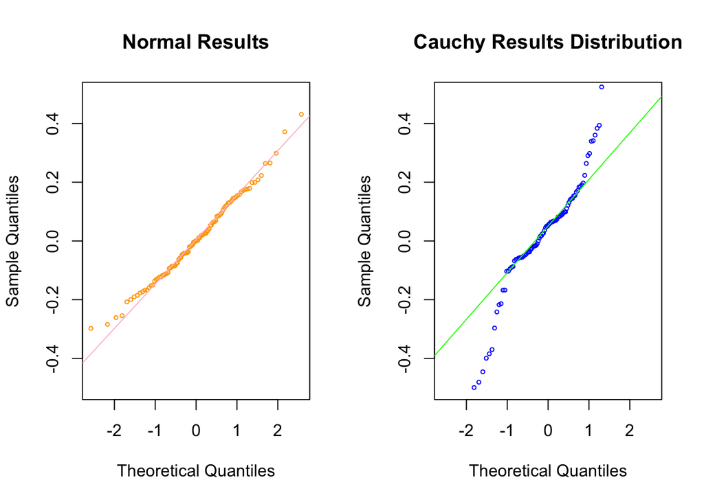

```r
par(mfrow = c(1, 2))
qqnorm(x,ylim=c(-.5,.5),cex=.5,col="orange",title("Normal Results"))
qqline(x,ylim=c(-.5,.5),col="pink")
qqnorm(y,ylim=c(-.5,.5),cex=.5,col="blue",title("Cauchy Results Distribution"))
qqline(y,ylim=c(-.5,.5),col="green")
```